# Probability

Gian Nicole Villamayor, Jessica Dela Cruz, John Lester Santos, John Rollic Conducto

7/16/2021

# Monty Hall Problem

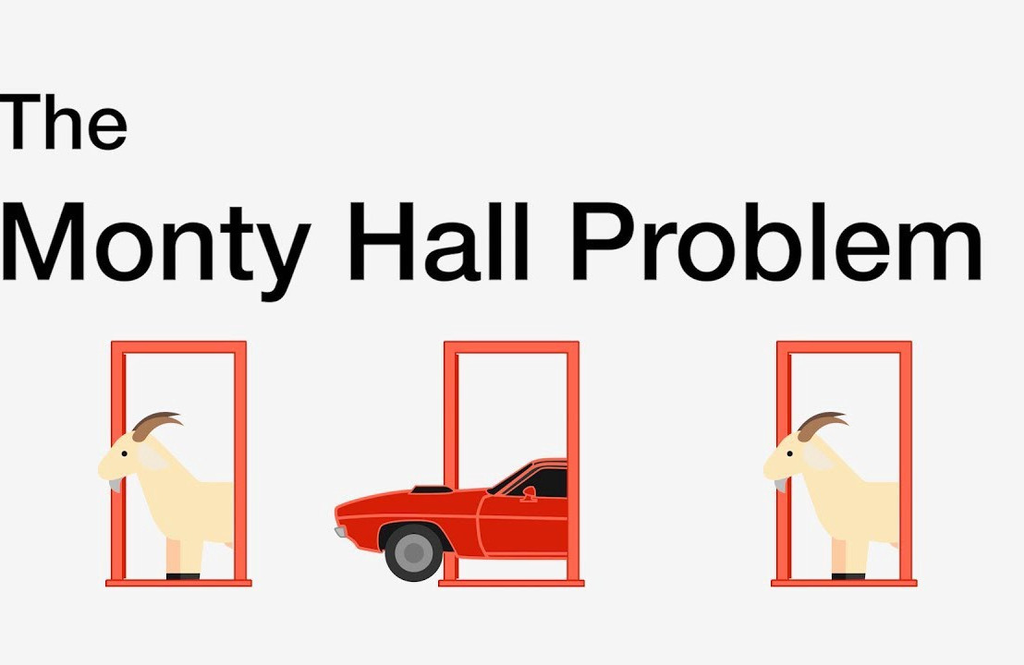

In the American TV game show called **“Let’s Make a Deal,”** a probability puzzle has challenged the minds of numerous statisticians, mathematicians, and scholars. The intriguing problem is named after the game show host, *Monty Hall*, and is currently known as the famous [**“Monty Hall Problem”**](https://www.statisticshowto.com/probability-and-statistics/monty-hall-problem/).

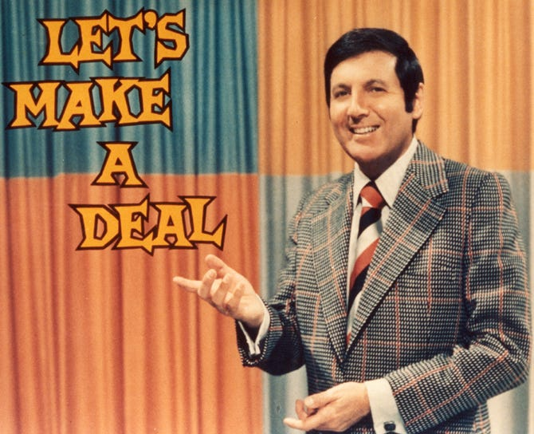

At the beginning of the game, the host presents **three doors** wherein the player can pick **exactly one** only. Behind one of these doors, a **brand new car** awaits the winner, while the remaining two hide the so-called [**“zonks”**](https://gameshows.fandom.com/wiki/Zonk)– unwanted booby prize. Their luck will be tested as they have a chance to bring home an extremely valuable prize. Initially, a blind test occurs since the player does not have any idea or basis on which door hides the precious car. After picking one, the host will then reveal one door containing zonk. The hardest decision-making lies after this, for the contestant will be given two options: **stay or switch**.

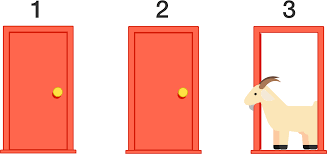

Consequently, an internal conflict will arise. Battle of thoughts will make it really hard for the contestant to make his or her final decision. One of these doors sits your *dream car* while the other one contains an *undesirable prize*. Indeed, the player will break into a cold sweat. This scenario leads to academic controversies that weigh the probability of winning the game.

[figure not shown]

To reduce the doubts and uncertainties, this problem is further analyzed, examined, and explained by several knowledgeable people. A common misconception is that the player will only have a *50/50 chance of winning* no matter what option he or she chooses. However, several scholars contradict this probability. **Marilyn vos Savant**, the person who has the highest recorded intelligence quotient, argues that the best option is to **switch**. [–Click here to know more about Marilyn vos Savant–](https://biography.yourdictionary.com/marilyn-vos-savant)

Will it really be an advantage if you switch?  
Can it really increase the odds of winning the car?

[This presentation from one of our groupmates, Rollic Conducto, will further tackle this issue.](https://youtu.be/EyNcAjdPV5c)

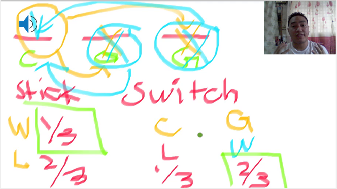

# Lotto Problem

One of the most popular major games of PCSO is the Ultra Lotto 6/58. At ₱20 per ticket, how much would a bettor spend to cover all of the possible combinations. Would the grand prize of ₱50 million cover all the expenses or it would simply incur a massive loss on the bettor?

[figure not shown]

**Ultra Lotto 6/58** is one of the lottery games in **PCSO(Philippine Charity Sweepstakes Office) Lottery Draw**. It is known by almost every Filipino and, for the record, there is a very small percentage of Filipinos who died without trying it even once. This game promises bettors to win millions of prizes when they got the right set of numbers in which **combination** is applied since **the order in which the numbers were drawn does not matter**, as long as you got the right set of numbers — **heaven is yours.**

[figure not shown]

The grand prize will be given if an individual chooses the correct **six-number combination**. Smaller prizes will be given for those who picked 5 or 4 numbers correctly. So for the price of 20 pesos, you could instantly win millions of cash, but how hard is it to win that prize?

**Solution:**

In computing for the number of six-number combinations that can be made from 1-58, **Combination** shall be used because the order of selection is not important. By using the formula of combination, there is a total of **40,475,358 combinations**. The odds of winning the lottery is therefore **1 in a 40,475,358** each draw. If a ticket costs ₱20, the bettor would have to spend **809,507,160 Pesos worth of tickets** in order to choose all of the 40,475,358 combinations. The overall expenses of the bettor is not covered by the 50 million grand prize because the bettor would still need 759,507,160 Pesos more to cover all the expenses.

In a more mathematical way, here is the explanation for the total amount to account all possibilities:

$$\LARGE {_{n}C_{k}=\frac{n!}{k!(n-k)!} }$$

Use the formula for combination without repetitions to determine how many combinations of numbers there are:

Here:  
n = total number of choices  
k = number of items we need to select  
Subtitute the values for n and k:

$$\LARGE {_{58}C_{6}=\frac{58!}{6!(58-6)!} }$$

Simplify and evaluate:

$$\large {=\frac{58!}{6!52!} }$$

$$\LARGE \hspace{20 mm}=40,475,358$$

After getting the no. of combinations, multiply it by 20 to determine how much would it cost to bet on all of the combinations:

$$\LARGE (40,475,358)(₱20)$$
$$\LARGE \hspace{0 mm}\fbox{=₱809,507,160}$$

Therefore, the grand prize 50 million pesos would not be enough to cover all the expenses and it would simply incur a massive loss on the bettor.

# References

Marilyn vos savant. (n.d.). Retrieved from https://biography.yourdictionary.com/marilyn-vos-savant

Monty Hall problem: Solution explained simply. (2021, June 13). Retrieved from https://www.statisticshowto.com/probability-and-statistics/monty-hall-problem/

Zonk: Game Shows Wiki. (n.d.). Retrieved from https://gameshows.fandom.com/wiki/Zonk